# Project - GWAS of eye color

```r
library(dplyr)
library(tidyverse)
library(qqman)
```

## Quality Control and Filtering

### Identification of individuals with elevated missing data rates or outlying heterozygosity rate

We want to filter out all samples that has a high rate of missing data, since that can be due low DNA quality. Furthermore, we want to filter samples with either high or low heterozygosity rate, since this could be a result of contamination of the sample. Both of these will bias the result.

To identify missing data rates, we run the following command from the shell prompt:  
`plink --bfile eye_color --missing --allow-no-sex --out eye_color`

This will output a file `eyecolor.imiss`, where the number and proportion of missing SNPs can be found.

To identify heterozygosity rate, we run the following command:  
`plink --bfile eye_color --het --allow-no-sex --out eye_color`

This will output a file `eyecolor.het`, where the number of homozygous genotypes (Hom), along with the number of non-missing genotypes per individual (NM), are specified. The observed heterozygosity rate per individual can then be calculated as:

- Het = (NM − Hom)/NM

```r
d_miss <- read.table("eye_color.imiss",header=T)
d_het <- read.table("eye_color.het",header=T)
d <- inner_join(d_miss,d_het)

d <- d %>%
    mutate(Het = (N.NM.-O.HOM.)/N.NM.)

head(d)
```

A data.frame: 6 × 11

|  | FID <int> | IID <int> | MISS_PHENO <chr> | N_MISS <int> | N_GENO <int> | F_MISS <dbl> | O.HOM. <int> | E.HOM. <dbl> | N.NM. <int> | F <dbl> | Het <dbl> |
| --- | --- | --- | --- | --- | --- | --- | --- | --- | --- | --- | --- |
| 1 | 1010 | 1010 | Y | 417559 | 958847 | 0.435500 | 355012 | 353100 | 522943 | 0.011510 | 0.3211268 |
| 2 | 1013 | 1013 | Y | 1589 | 958847 | 0.001657 | 622171 | 618900 | 897402 | 0.011880 | 0.3066976 |
| 3 | 1020 | 1020 | Y | 3555 | 958847 | 0.003708 | 620700 | 617700 | 895619 | 0.010850 | 0.3069598 |
| 4 | 1022 | 1022 | Y | 23735 | 958847 | 0.024750 | 609152 | 605200 | 877300 | 0.014590 | 0.3056514 |
| 5 | 1024 | 1024 | Y | 23896 | 958847 | 0.024920 | 606768 | 605000 | 876929 | 0.006683 | 0.3080763 |
| 6 | 1026 | 1026 | Y | 23264 | 958847 | 0.024260 | 611711 | 605300 | 877569 | 0.023400 | 0.3029483 |

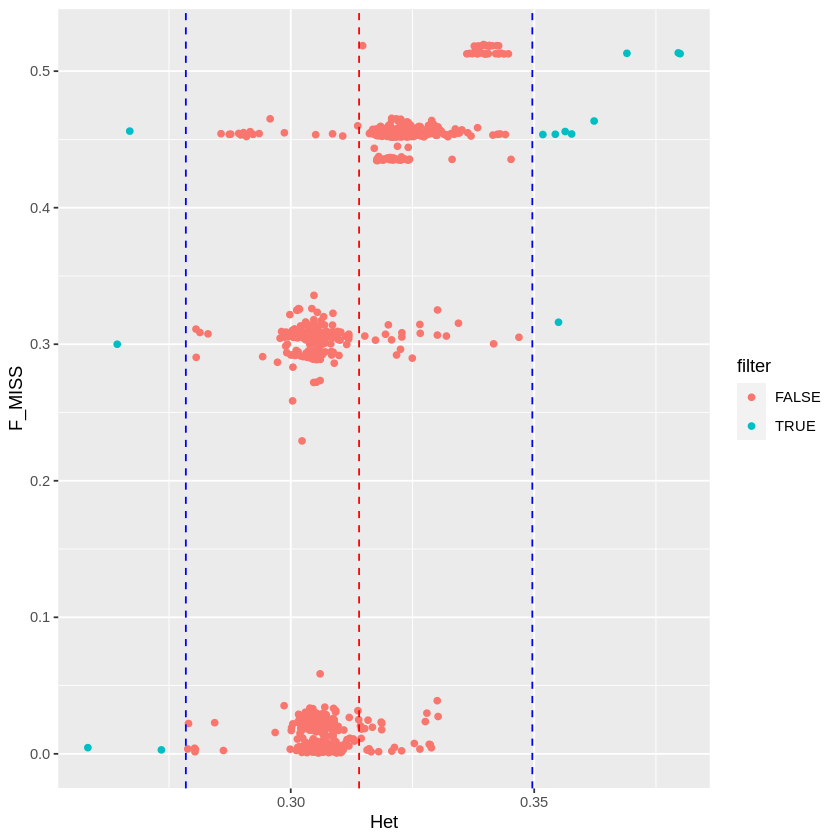

```r
Het_mean  <- mean(d$Het)
Het_SD  <- sd(d$Het)

d %>%
    mutate(filter = abs(Het-Het_mean) > 3*Het_SD) %>%
    ggplot() +
        geom_point(aes(x = Het, y = F_MISS, color = filter)) +
        geom_vline(xintercept = Het_mean, color = "red", linetype = "dashed") +
        geom_vline(xintercept = Het_mean-3*Het_SD, color = "blue", linetype = "dashed") +
        geom_vline(xintercept = Het_mean+3*Het_SD, color = "blue", linetype = "dashed")
```

### Identification of duplicated or related individuals

We also want to filter related individuals and to do this, we calculate an identity by descent (IBD) matrix. This can be done using PLINK, but it works best with non-correlated SNPs. Therefore, we prune the data such that no SNP pair has an r^2 value above some threshold. We do that using the following command:  
`plink --bfile eye_color --indep-pairwise 500kb 5 0.2 --out eye_color`

This will output a file `eye_color.prune.in` with the independent SNPs. This file can now be used to calculate IBD between each pair of individuals. The following PLINK command is used:  
`plink --bfile eye_color --extract eye_color.prune.in --genome --min 0.09 --out eye_color`

This will output a file `eye_color.genome`. The calculated IBD will only be printet in this file if it is above 0.09 (mean value between third degree relatives (0.125), and fourth degree relatives (0.0625)). PI_HAT shows how much of the genome two individuals share. 1 = identical twins, 0.5 = siblings.

```r
ibd <- read.table('eye_color.genome', header = TRUE)
head(ibd)

members <- ibd$FID1
members <- unique(members)
members
paste("There are", length(members), "related individuals")

#write.table(cbind(members,members), file = 'wrong_ibd.txt', col.names = F, row.names = F)
```

A data.frame: 6 × 14

|  | FID1 <int> | IID1 <int> | FID2 <int> | IID2 <int> | RT <chr> | EZ <lgl> | Z0 <dbl> | Z1 <dbl> | Z2 <dbl> | PI_HAT <dbl> | PHE <int> | DST <dbl> | PPC <dbl> | RATIO <dbl> |
| --- | --- | --- | --- | --- | --- | --- | --- | --- | --- | --- | --- | --- | --- | --- |
| 1 | 1173 | 1173 | 4814 | 4814 | UN | NA | 0.0000 | 0.0000 | 1.0000 | 1.0000 | -1 | 1.000000 | 1 | NA |
| 2 | 1239 | 1239 | 3048 | 3048 | UN | NA | 0.7957 | 0.2043 | 0.0000 | 0.1021 | -1 | 0.766343 | 1 | 2.6430 |
| 3 | 1239 | 1239 | 5867 | 5867 | UN | NA | 0.7957 | 0.2043 | 0.0000 | 0.1022 | -1 | 0.766366 | 1 | 2.5188 |
| 4 | 1259 | 1259 | 3048 | 3048 | UN | NA | 0.7900 | 0.2100 | 0.0000 | 0.1050 | -1 | 0.766533 | 1 | 2.6521 |
| 5 | 1259 | 1259 | 5867 | 5867 | UN | NA | 0.7506 | 0.2494 | 0.0000 | 0.1247 | -1 | 0.766517 | 1 | 2.8049 |
| 6 | 1269 | 1269 | 1275 | 1275 | UN | NA | 0.0016 | 0.9588 | 0.0396 | 0.5190 | -1 | 0.873488 | 1 | 1847.0000 |

1. 1173

2. 1239

3. 1259

4. 1269

5. 1338

6. 1375

7. 1424

8. 1659

9. 1678

10. 1775

11. 1877

12. 2513

13. 2651

14. 2887

15. 3048

16. 3783

17. 3998

18. 4198

19. 4460

20. 4547

21. 4583

22. 4584

23. 4897

24. 5792

25. 651

26. 8915

27. 9277

'There are 27 related individuals'

### SNPs with an excessive missing data rate

```r
d_lmiss <- read.table("eye_color.lmiss", header = T)
```

```
Warning message:
“Removed 1766 rows containing non-finite values (stat_bin).”
```

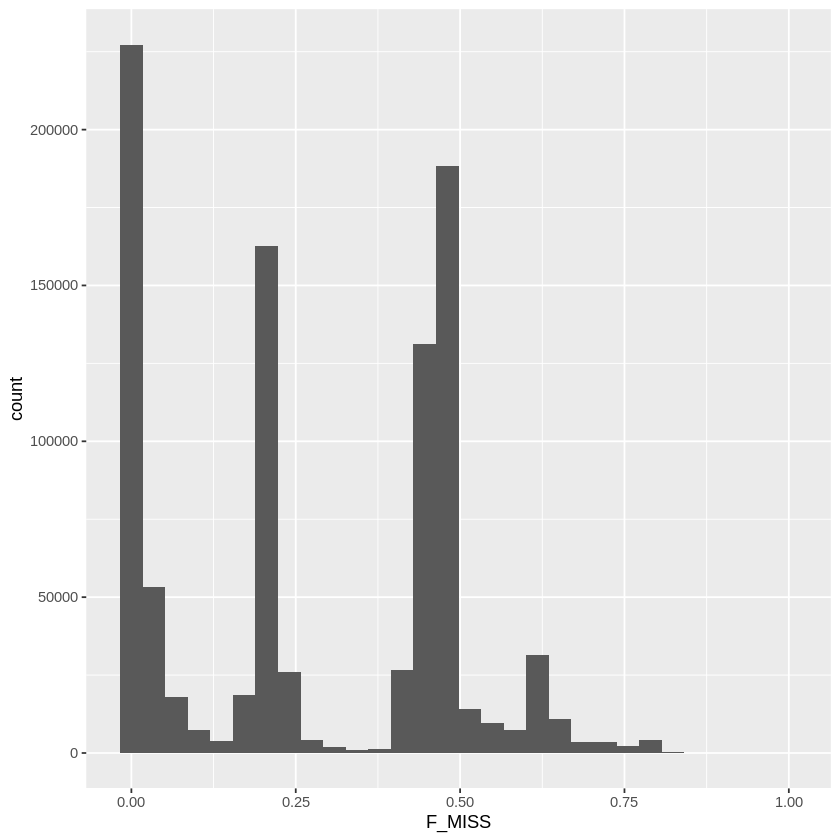

```r
d_lmiss %>%
    ggplot(aes(x=F_MISS)) +
    geom_histogram()
```

We use this command to filter away variants that deviate more from HW than p<1e-5. I also filter minor allele frequence of less than 0.01 and remove SNPs with a call rate less than 0.25 (--geno option)  
`plink --bfile eye_color --remove wrong_ibd.txt --geno 0.75 --hwe 0.00001 --maf 0.01 --make-bed --out eye_color-QC`

Now we have 837498 variants and 1260 people left in the dataset. In total we have filtered for related individuals, strong deviation from HW, minor allele frequency less than set treshold and SNPs with call rate less than treshold.

# Defining phenotypes

#### Light eyes vs dark eyes

We have to define a binary input for the eyecolor status.

```r
eyecolor <- read.table("eye_color.txt", header = F)
names(eyecolor) <- c("IID", "eye_color")

eyecolor %>%
    group_by(eye_color) %>%
    summarize(n = n())
```

A tibble: 12 × 2

|  | eye_color <chr> | n <int> |
| --- | --- | --- |
| 1 | amber-brown | 4 |
| 2 | blue | 246 |
| 3 | blue-green | 92 |
| 4 | blue-green-gold | 4 |
| 5 | blue-green-grey | 17 |
| 6 | blue-grey | 119 |
| 7 | brown | 364 |
| 8 | dark_blue | 15 |
| 9 | dark_brown | 56 |
| 10 | green | 122 |
| 11 | green-gray | 8 |
| 12 | hazel/brown-green | 240 |

```r
binary_eyecolor <- eyecolor %>%
    mutate(FID = IID) %>%
    mutate(response = case_when(eye_color == "amber-brown" ~ 2,
                                eye_color == "brown" ~ 2,
                                eye_color == "dark_brown" ~ 2,
                                eye_color == "hazel/brown-green" ~ 2,
                                TRUE ~ 1)) %>%
    select(FID, IID, response)

head(binary_eyecolor)
dim(binary_eyecolor)

#write.table(binary_eyecolor, file = "brown_vs_rest.txt", sep = " ", col.names = F, row.names = F)
```

A data.frame: 6 × 3

|  | FID <int> | IID <int> | response <dbl> |
| --- | --- | --- | --- |
| 1 | 1010 | 1010 | 2 |
| 2 | 1013 | 1013 | 2 |
| 3 | 1020 | 1020 | 1 |
| 4 | 1022 | 1022 | 1 |
| 5 | 1024 | 1024 | 1 |
| 6 | 1026 | 1026 | 2 |

1. 1287

2. 3

# PCA

It is best to do PCA on an LD-pruned set of SNPs. Therefore, we use the follwing command to prune the dataset:  
`plink --bfile eye_color-QC --indep-pairwise 500kb 5 0.2 --out eye_color-QC`

This creates a `.prune.in` and a `.prune.out` file. Now, to use the pruned SNPs to calculate a relationship matrix and the first 20 PCs, we run this command:  
`plink --bfile eye_color-QC --extract eye_color-QC.prune.in --pca 20 --out eye_color-QC`

This calculates the eigenvalues and eigenvectors.

```r
eigenvec <- read.table("eye_color-QC.eigenvec", header = F)
head(eigenvec)
dim(eigenvec)
```

A data.frame: 6 × 22

|  | V1 <int> | V2 <int> | V3 <dbl> | V4 <dbl> | V5 <dbl> | V6 <dbl> | V7 <dbl> | V8 <dbl> | V9 <dbl> | V10 <dbl> | ⋯ | V13 <dbl> | V14 <dbl> | V15 <dbl> | V16 <dbl> | V17 <dbl> | V18 <dbl> | V19 <dbl> | V20 <dbl> | V21 <dbl> | V22 <dbl> |
| --- | --- | --- | --- | --- | --- | --- | --- | --- | --- | --- | --- | --- | --- | --- | --- | --- | --- | --- | --- | --- | --- |
| 1 | 1010 | 1010 | 0.00186361 | -0.00595087 | 0.02187750 | 0.01278490 | 0.02003310 | -0.01270480 | 3.00830e-03 | -0.003693170 | ⋯ | -0.01173650 | 0.00928513 | 0.00735282 | -0.015368300 | 0.00864294 | 0.015732300 | 0.002466140 | -0.003456180 | -0.001591140 | -0.00761695 |
| 2 | 1013 | 1013 | 0.01182980 | -0.00212206 | -0.01287550 | -0.00916655 | -0.00913004 | -0.00113367 | 1.88023e-03 | -0.002384190 | ⋯ | -0.00259373 | 0.00829078 | 0.00221898 | 0.000614906 | 0.00293616 | -0.002587290 | 0.005794570 | -0.005711070 | -0.005347950 | -0.00766870 |
| 3 | 1020 | 1020 | 0.01035490 | -0.00508999 | -0.01415360 | -0.01194530 | -0.00787076 | -0.00295176 | -3.18942e-05 | 0.001515130 | ⋯ | -0.00276107 | -0.00633277 | -0.00573836 | 0.005945100 | 0.00782449 | -0.000470341 | -0.000956082 | 0.006623060 | 0.000698147 | 0.00544821 |
| 4 | 1022 | 1022 | 0.01122920 | -0.00268797 | -0.01210510 | -0.00925893 | -0.00509233 | -0.00790253 | -1.37015e-03 | 0.008814620 | ⋯ | -0.01169910 | -0.00372389 | -0.00248874 | 0.002718760 | -0.00128260 | -0.005774430 | 0.001988260 | -0.003259040 | 0.002005190 | 0.00760142 |
| 5 | 1024 | 1024 | 0.00715355 | -0.00179215 | -0.00602916 | -0.00454150 | 0.00140583 | 0.00293056 | 1.80199e-03 | 0.002275140 | ⋯ | 0.00538757 | -0.00625709 | -0.01028530 | -0.002641920 | -0.00226604 | 0.006617140 | -0.000449053 | 0.000898369 | 0.000171410 | 0.01140750 |
| 6 | 1026 | 1026 | 0.01031880 | -0.00296708 | -0.01419620 | -0.00953844 | -0.00256996 | -0.00527398 | -8.02986e-03 | 0.000700263 | ⋯ | -0.00085809 | -0.00481554 | -0.00780685 | -0.001326430 | -0.00688199 | -0.000746695 | 0.001062150 | 0.008509600 | -0.000161794 | -0.01317770 |

1. 1260

2. 22

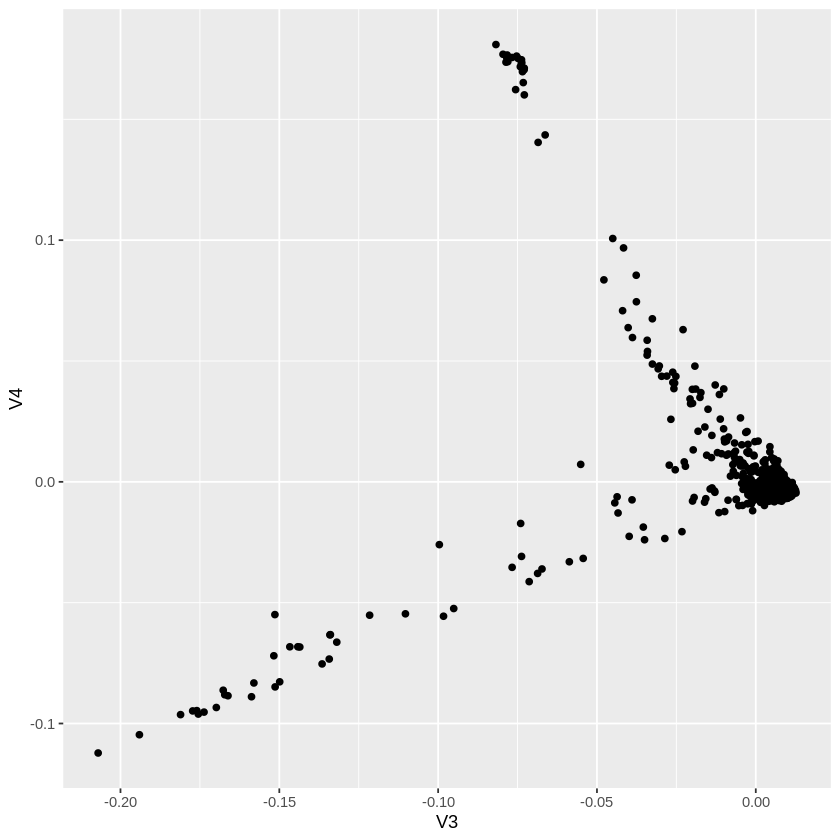

```r
ggplot(data = eigenvec) +
    geom_point(aes(x = V3, y = V4))
```

We can color this plot according to some phenotype like this:

```r
resp <- binary_eyecolor %>%
    filter(!(FID %in% members))
```

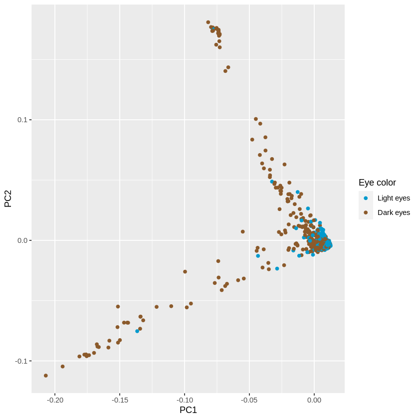

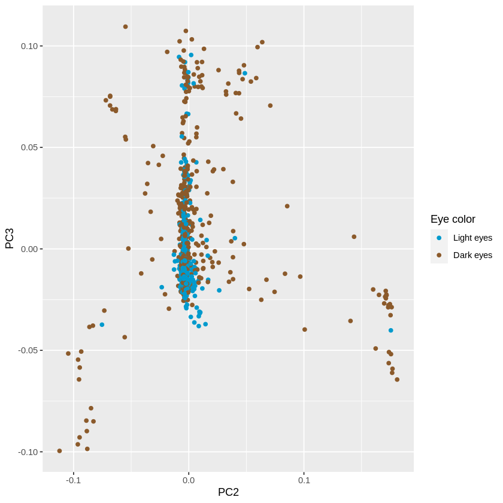

```r
eigenvec <- eigenvec %>%
    mutate(response = factor(resp$response))

ggplot(data = eigenvec) +
    geom_point(aes(x = V3, y = V4, color = response)) +
    scale_color_manual(values = c("1" = "deepskyblue3", "2"="tan4"), labels = c("Light eyes", "Dark eyes"), name = "Eye color") +
    xlab("PC1") +
    ylab("PC2")

ggplot(data = eigenvec) +
    geom_point(aes(x = V4, y = V5, color = response)) +
    scale_color_manual(values = c("1"= "deepskyblue3", "2"="tan4"), labels = c("Light eyes", "Dark eyes"), name = "Eye color") +
    xlab("PC2") +
    ylab("PC3")
```

### Variance explained by each PC

```r
eigenval <- read.table("eye_color-QC.eigenval", header = F)

eigenval <- eigenval %>%
    mutate(variance_expl = V1/sum(V1)*100) %>%
    mutate(PC = seq(1,20)) %>%
    mutate(cumsum = cumsum(variance_expl))

head(eigenval)
```

A data.frame: 6 × 4

|  | V1 <dbl> | variance_expl <dbl> | PC <int> | cumsum <dbl> |
| --- | --- | --- | --- | --- |
| 1 | 26.59790 | 36.059297 | 1 | 36.05930 |
| 2 | 12.09160 | 16.392820 | 2 | 52.45212 |
| 3 | 3.15889 | 4.282569 | 3 | 56.73469 |
| 4 | 2.84998 | 3.863774 | 4 | 60.59846 |
| 5 | 2.28265 | 3.094634 | 5 | 63.69309 |
| 6 | 2.19551 | 2.976496 | 6 | 66.66959 |

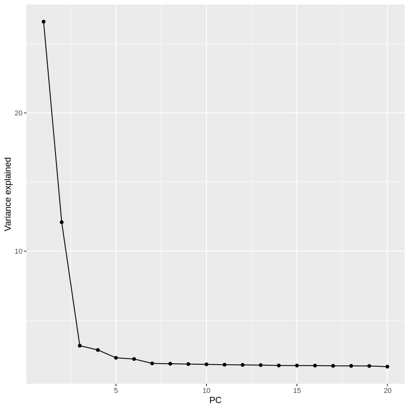

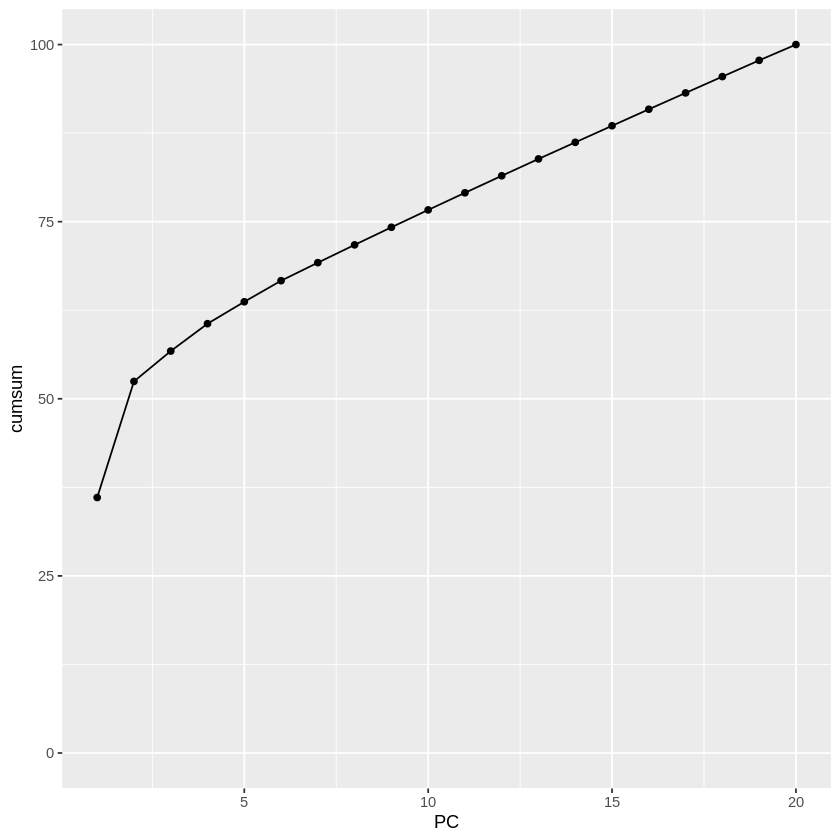

```r
eigenval %>%
    ggplot() +
        geom_line(aes(x = PC, y = V1)) +
        geom_point(aes(x = PC, y = V1)) +
        ylab("Variance explained")

eigenval %>%
    ggplot() +
        geom_line(aes(x = PC, y = cumsum)) +
        geom_point(aes(x = PC, y = cumsum)) +
        ylim(0,100)
```

## Association testing using PLINK

### Test for association with eyecolor status using a Fisher’s exact test

To do the Fisher's exact test, we type the following command:  
`plink --bfile eye_color-QC --assoc fisher --allow-no-sex --pheno brown_vs_rest.txt --out brown_vs_rest`

This produces a `brown_vs_rest.assoc.fisher` output file.

```r
assoc_fisher <- read.table("brown_vs_rest.assoc.fisher", header = T)
dim(assoc_fisher)
```

1. 837498

2. 9

```r
head(assoc_fisher %>%
    arrange(P))
```

A data.frame: 6 × 9

|  | CHR <int> | SNP <chr> | BP <int> | A1 <chr> | F_A <dbl> | F_U <dbl> | A2 <chr> | P <dbl> | OR <dbl> |
| --- | --- | --- | --- | --- | --- | --- | --- | --- | --- |
| 1 | 15 | rs1667394 | 28530182 | C | 0.3990 | 0.04570 | T | 2.193e-101 | 13.8600 |
| 2 | 15 | rs916977 | 28513364 | T | 0.3866 | 0.04520 | C | 7.369e-94 | 13.3200 |
| 3 | 15 | rs8039195 | 28516084 | C | 0.3537 | 0.04461 | T | 3.806e-73 | 11.7200 |
| 4 | 15 | rs4778241 | 28338713 | A | 0.3607 | 0.07980 | C | 1.840e-68 | 6.5050 |
| 5 | 15 | rs11636232 | 28386626 | T | 0.1894 | 0.48990 | C | 2.547e-57 | 0.2432 |
| 6 | 15 | rs3935591 | 28374012 | T | 0.3813 | 0.04062 | C | 7.815e-56 | 14.5600 |

```r
sign <- assoc_fisher %>%
    mutate(significant = P <= (5e-8)) %>%
    arrange(P)

head(sign)
sum(sign$significant)
```

A data.frame: 6 × 10

|  | CHR <int> | SNP <chr> | BP <int> | A1 <chr> | F_A <dbl> | F_U <dbl> | A2 <chr> | P <dbl> | OR <dbl> | significant <lgl> |
| --- | --- | --- | --- | --- | --- | --- | --- | --- | --- | --- |
| 1 | 15 | rs1667394 | 28530182 | C | 0.3990 | 0.04570 | T | 2.193e-101 | 13.8600 | TRUE |
| 2 | 15 | rs916977 | 28513364 | T | 0.3866 | 0.04520 | C | 7.369e-94 | 13.3200 | TRUE |
| 3 | 15 | rs8039195 | 28516084 | C | 0.3537 | 0.04461 | T | 3.806e-73 | 11.7200 | TRUE |
| 4 | 15 | rs4778241 | 28338713 | A | 0.3607 | 0.07980 | C | 1.840e-68 | 6.5050 | TRUE |
| 5 | 15 | rs11636232 | 28386626 | T | 0.1894 | 0.48990 | C | 2.547e-57 | 0.2432 | TRUE |
| 6 | 15 | rs3935591 | 28374012 | T | 0.3813 | 0.04062 | C | 7.815e-56 | 14.5600 | TRUE |

698

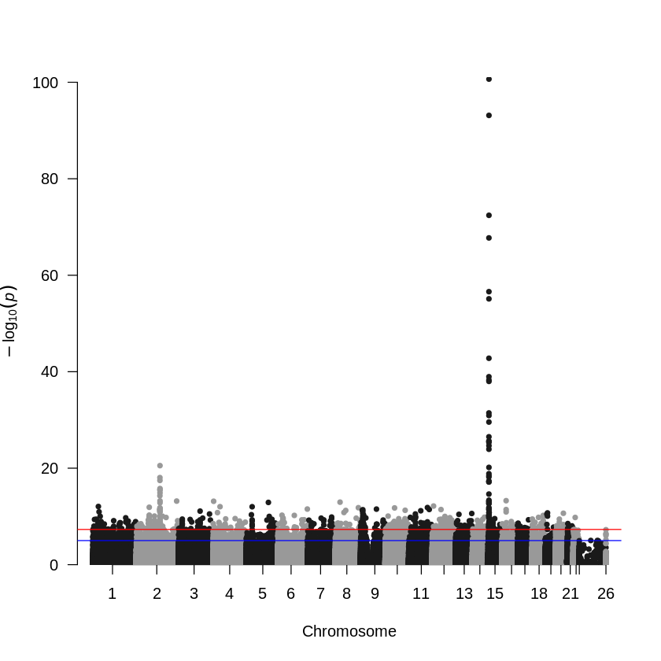

```r
manhattan(assoc_fisher)
```

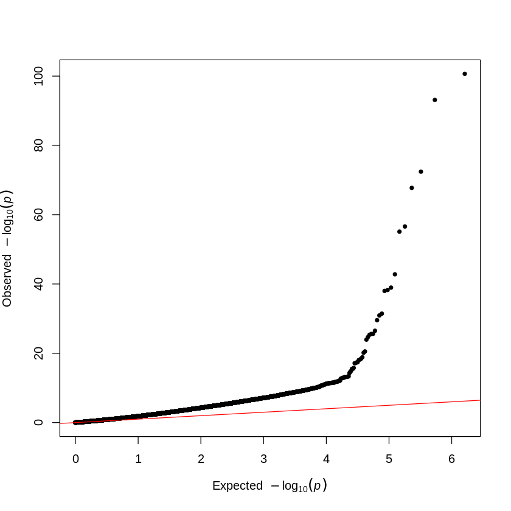

```r
qq(assoc_fisher$P)
```

### Genomic control

```r
chisq <- assoc_fisher %>%
    mutate(Chi_squared = qchisq(P, df=1, lower.tail = F))

set.seed(1)
null_chisq <- tibble(Chi_squared = rchisq(nrow(assoc_fisher), df = 1))

sample_chi_median  <- median(chisq$Chi_squared)
null_chi_median <- median(null_chisq$Chi_squared)

(lambda <- sample_chi_median/null_chi_median)
paste("The inflation factor is", lambda)
```

1.94660298884729

'The inflation factor is 1.94660298884729'

```r
adjusted <- chisq %>%
    mutate(adj_chi = Chi_squared/lambda) %>%
    mutate(adj_P = pchisq(adj_chi, df=1, lower.tail = F)) %>%
    arrange(adj_P)
head(adjusted)
```

A data.frame: 6 × 12

|  | CHR <int> | SNP <chr> | BP <int> | A1 <chr> | F_A <dbl> | F_U <dbl> | A2 <chr> | P <dbl> | OR <dbl> | Chi_squared <dbl> | adj_chi <dbl> | adj_P <dbl> |
| --- | --- | --- | --- | --- | --- | --- | --- | --- | --- | --- | --- | --- |
| 1 | 15 | rs1667394 | 28530182 | C | 0.3990 | 0.04570 | T | 2.193e-101 | 13.8600 | 456.9711 | 234.7531 | 5.480435e-53 |
| 2 | 15 | rs916977 | 28513364 | T | 0.3866 | 0.04520 | C | 7.369e-94 | 13.3200 | 422.3892 | 216.9879 | 4.106089e-49 |
| 3 | 15 | rs8039195 | 28516084 | C | 0.3537 | 0.04461 | T | 3.806e-73 | 11.7200 | 327.2559 | 168.1164 | 1.907998e-38 |
| 4 | 15 | rs4778241 | 28338713 | A | 0.3607 | 0.07980 | C | 1.840e-68 | 6.5050 | 305.7512 | 157.0691 | 4.943659e-36 |
| 5 | 15 | rs11636232 | 28386626 | T | 0.1894 | 0.48990 | C | 2.547e-57 | 0.2432 | 254.6257 | 130.8052 | 2.731426e-30 |
| 6 | 15 | rs3935591 | 28374012 | T | 0.3813 | 0.04062 | C | 7.815e-56 | 14.5600 | 247.8052 | 127.3014 | 1.596010e-29 |

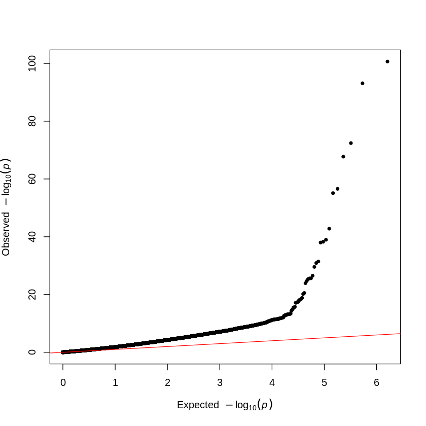

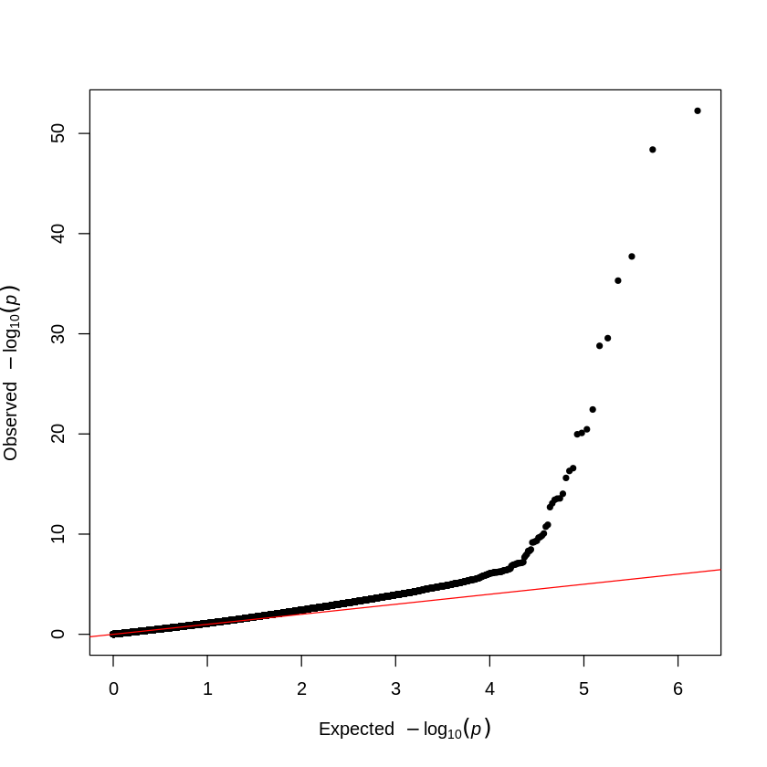

```r
qq(assoc_fisher$P)

qq(adjusted$adj_P)
```

### Adjusting for PCs

We can use logistic regression test to perform an association test while correcting for covariates. To include the first 2 PCs as a covariate we type:  
`plink --bfile eye_color-QC --pheno brown_vs_rest.txt --allow-no-sex --logistic --covar eye_color-QC.eigenvec --covar-number 1-2`

The output file `plink.assoc.logistic` contains p-values for both the SNPs and the covariates.

```r
logistic <- read.table("plink.assoc.logistic", header = T)

head(logistic)
dim(logistic)
```

A data.frame: 6 × 9

|  | CHR <int> | SNP <chr> | BP <int> | A1 <chr> | TEST <chr> | NMISS <int> | OR <dbl> | STAT <dbl> | P <dbl> |
| --- | --- | --- | --- | --- | --- | --- | --- | --- | --- |
| 1 | 1 | rs3094315 | 752566 | G | ADD | 556 | 9.553e-01 | -0.2618 | 7.935e-01 |
| 2 | 1 | rs3094315 | 752566 | G | COV1 | 556 | 5.607e-23 | -3.0200 | 2.528e-03 |
| 3 | 1 | rs3094315 | 752566 | G | COV2 | 556 | 2.460e+01 | 0.2333 | 8.156e-01 |
| 4 | 1 | rs3131972 | 752721 | A | ADD | 1219 | 8.723e-01 | -1.1740 | 2.402e-01 |
| 5 | 1 | rs3131972 | 752721 | A | COV1 | 1219 | 1.072e-30 | -5.5520 | 2.817e-08 |
| 6 | 1 | rs3131972 | 752721 | A | COV2 | 1219 | 6.107e+00 | 0.1678 | 8.667e-01 |

1. 2512494

2. 9

```r
SNPs <- logistic %>%
    filter(TEST == "ADD") %>%
    filter(!(is.na(P)))

head(SNPs %>% arrange(P))
```

A data.frame: 6 × 9

|  | CHR <int> | SNP <chr> | BP <int> | A1 <chr> | TEST <chr> | NMISS <int> | OR <dbl> | STAT <dbl> | P <dbl> |
| --- | --- | --- | --- | --- | --- | --- | --- | --- | --- |
| 1 | 15 | rs1667394 | 28530182 | C | ADD | 1147 | 14.7200 | 15.60 | 7.374e-55 |
| 2 | 15 | rs916977 | 28513364 | T | ADD | 1111 | 13.1000 | 14.73 | 4.114e-49 |
| 3 | 15 | rs8039195 | 28516084 | C | ADD | 998 | 12.0000 | 13.42 | 4.580e-41 |
| 4 | 15 | rs4778241 | 28338713 | A | ADD | 1260 | 6.1350 | 13.36 | 1.050e-40 |
| 5 | 15 | rs11636232 | 28386626 | T | ADD | 1235 | 0.2885 | -11.86 | 1.816e-32 |
| 6 | 15 | rs3935591 | 28374012 | T | ADD | 636 | 14.9200 | 11.33 | 9.572e-30 |

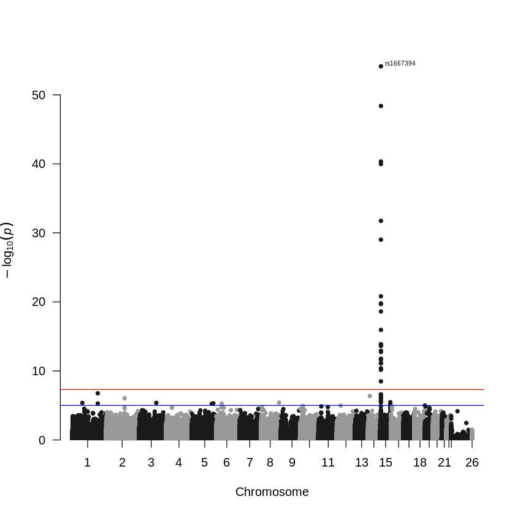

```r
manhattan(SNPs, annotatePval = 5e-8)
```

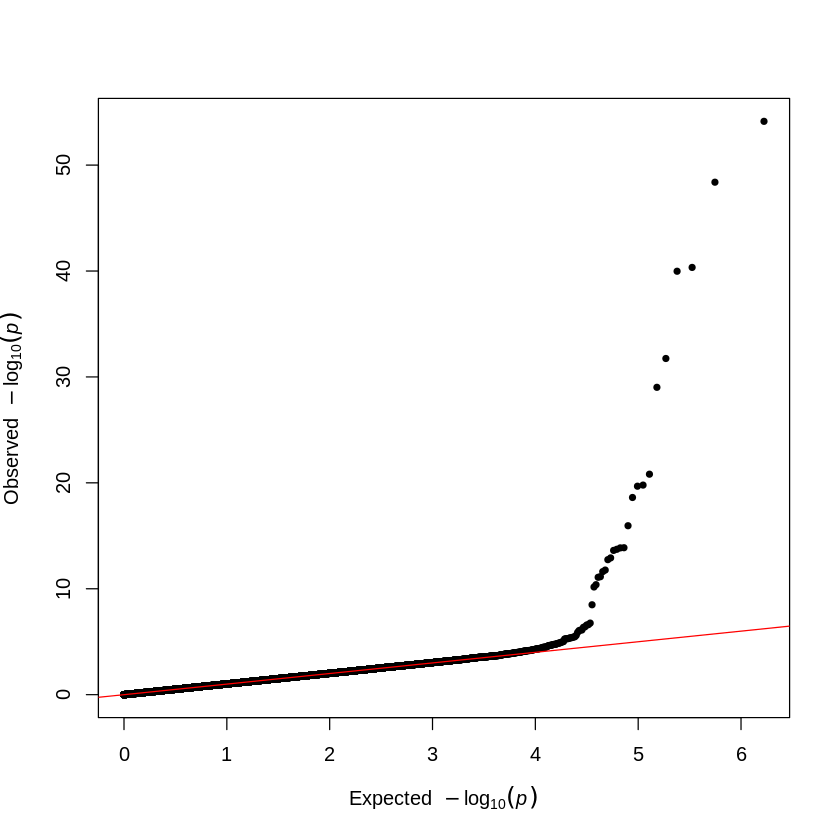

```r
qq(SNPs$P)
```

If we use a significance treshold of 5e-8 (the red line in the manhattan plot), we get the following significant SNPs:

```r
significant <- SNPs %>%
    mutate(significant = P <= 5e-8) %>%
    filter(significant == TRUE) %>%
    arrange(P)

sum(significant$significant == TRUE)
head(significant)
```

24

A data.frame: 6 × 10

|  | CHR <int> | SNP <chr> | BP <int> | A1 <chr> | TEST <chr> | NMISS <int> | OR <dbl> | STAT <dbl> | P <dbl> | significant <lgl> |
| --- | --- | --- | --- | --- | --- | --- | --- | --- | --- | --- |
| 1 | 15 | rs1667394 | 28530182 | C | ADD | 1147 | 14.7200 | 15.60 | 7.374e-55 | TRUE |
| 2 | 15 | rs916977 | 28513364 | T | ADD | 1111 | 13.1000 | 14.73 | 4.114e-49 | TRUE |
| 3 | 15 | rs8039195 | 28516084 | C | ADD | 998 | 12.0000 | 13.42 | 4.580e-41 | TRUE |
| 4 | 15 | rs4778241 | 28338713 | A | ADD | 1260 | 6.1350 | 13.36 | 1.050e-40 | TRUE |
| 5 | 15 | rs11636232 | 28386626 | T | ADD | 1235 | 0.2885 | -11.86 | 1.816e-32 | TRUE |
| 6 | 15 | rs3935591 | 28374012 | T | ADD | 636 | 14.9200 | 11.33 | 9.572e-30 | TRUE |

```r
chisq_PCA <- SNPs %>%
    mutate(Chi_squared = qchisq(P, df=1, lower.tail = F))

set.seed(1)
null_chisq_PCA <- tibble(Chi_squared = rchisq(nrow(SNPs), df = 1))

sample_chi_median_PCA  <- median(chisq_PCA$Chi_squared)
null_chi_median_PCA <- median(null_chisq_PCA$Chi_squared)

(lambda_PCA <- sample_chi_median_PCA/null_chi_median_PCA)

paste('The inflation factor is now', lambda_PCA)
```

1.02620866414242

'The inflation factor is now 1.02620866414242'

## SNPs at significant loci

I use this funtion to compute the genotypes for the SNPs, with a window around 200 kb

`plink --bfile eye_color-QC --pheno brown_vs_rest.txt --allow-no-sex --recode A 'include-alt' --snp rs1667394 --window 200 --out new_text_fileset`

```r
genotypes <- read.table("new_text_fileset.raw", header = T)
```

```r
head(genotypes)
dim(genotypes)
```

A data.frame: 6 × 13

|  | FID <int> | IID <int> | PAT <int> | MAT <int> | SEX <int> | PHENOTYPE <int> | rs6497287_C..T. <int> | rs8028689_C..T. <int> | rs916977_T..C. <int> | rs8039195_C..T. <int> | rs16950987_A..G. <int> | rs1667394_C..T. <int> | rs1667400_A..C. <int> |
| --- | --- | --- | --- | --- | --- | --- | --- | --- | --- | --- | --- | --- | --- |
| 1 | 1010 | 1010 | 0 | 0 | 0 | 2 | NA | 0 | NA | 0 | 0 | 1 | NA |
| 2 | 1013 | 1013 | 0 | 0 | 0 | 2 | 1 | 0 | 1 | 1 | 0 | 1 | 0 |
| 3 | 1020 | 1020 | 0 | 0 | 0 | 1 | 0 | 0 | 0 | 0 | 0 | 0 | 0 |
| 4 | 1022 | 1022 | 0 | 0 | 0 | 1 | 0 | 0 | 0 | 0 | 0 | 0 | 0 |
| 5 | 1024 | 1024 | 0 | 0 | 0 | 1 | 0 | 0 | 0 | 0 | 0 | 0 | 0 |
| 6 | 1026 | 1026 | 0 | 0 | 0 | 2 | 0 | 0 | 0 | 0 | 0 | 0 | 0 |

1. 1260

2. 13

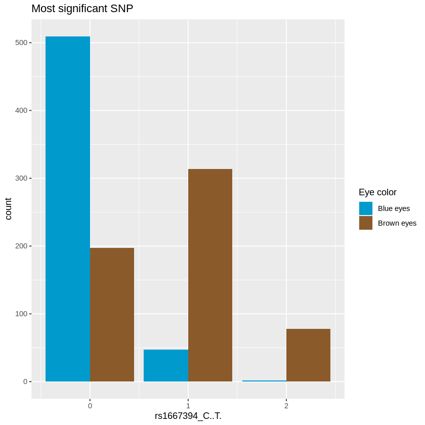

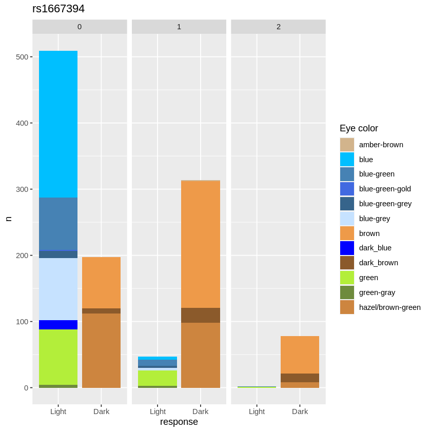

```r
eye_col <- eyecolor %>%
    filter(!(IID %in% members))

most_sig <- genotypes %>%
    select(matches('rs1667394')) %>%
    mutate(response = factor(resp$response)) %>%
    mutate(eye_col = eye_col$eye_color)  %>%
    drop_na()

group <- most_sig %>%
    group_by(rs1667394_C..T., response, eye_col) %>%
    summarise(n = n())

colors <- c("blue"= "deepskyblue",
            "blue-green" = "steelblue",
            "blue-green-gold" = "royalblue",
            "blue-green-grey" = "steelblue4",
            "blue-grey" = "slategray1",
            "dark_blue" = "blue",
            "green" = "olivedrab2",
            "green-gray" = "darkolivegreen4",
            "brown" = "tan2",
            "dark_brown" = "tan4",
            "hazel/brown-green" = "tan3",
            "amber-brown" = "tan")

levels(colors) <- c("dark_blue", "blue", "blue-green-gold", "blue-green-grey",
                   "blue-grey", "blue-green", "green", "green-gray", "brown",
                   "dark_brown", "amber-brown", "hazel/brown-green")

ggplot(data = most_sig, aes(x = rs1667394_C..T., y = ..count..)) +
    geom_bar(aes(fill = response), position = "dodge") +
    ggtitle('Most significant SNP') +
    scale_fill_manual(values = c("1"= "deepskyblue3", "2"="tan4"), labels = c("Blue eyes", "Brown eyes"), name = "Eye color")

ggplot(data = group, aes(x = response, y = n, fill = eye_col)) +
    geom_bar(stat="identity") +
    labs(title = 'rs1667394') +
    facet_wrap(~ rs1667394_C..T., scales = "free_x") +
    scale_fill_manual(values = colors, name = "Eye color") +
    scale_x_discrete(labels = c("1" = "Light", "2" = "Dark"))
```

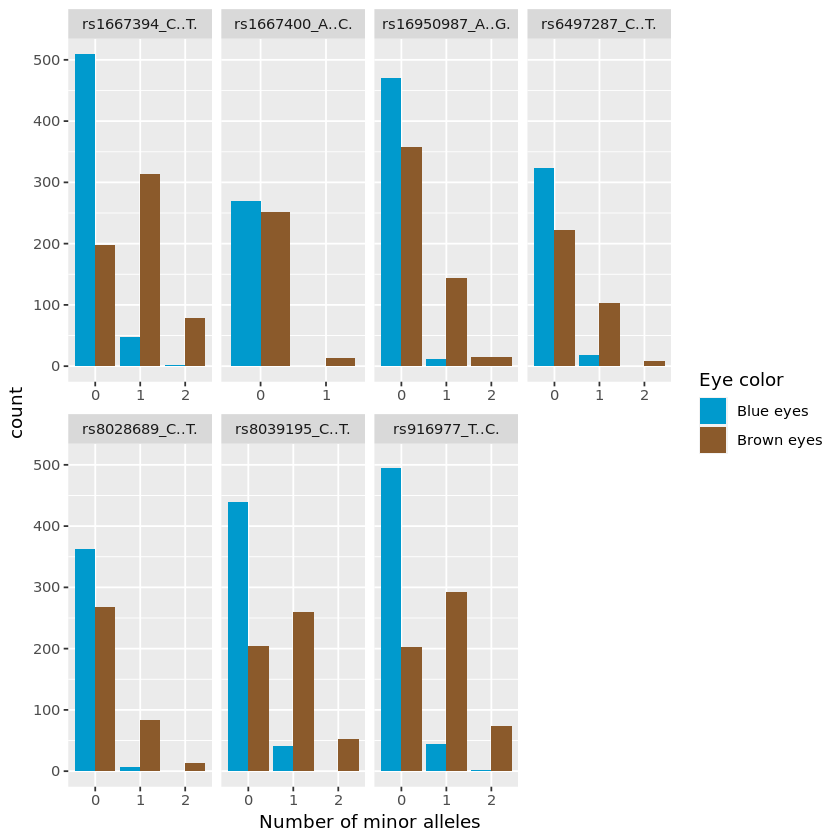

```r
data_long <- tidyr::gather(genotypes, key = variable, value = value, -c(FID, IID, PAT, MAT, SEX, PHENOTYPE)) %>%
    drop_na()

ggplot(data_long, aes(x = factor(value), fill = factor(PHENOTYPE))) +
    geom_bar(position = "dodge") +
    facet_wrap(~ variable, scales = "free_x", nrow = 2) +
    xlab("Number of minor alleles") +
    scale_fill_manual(values = c("1"= "deepskyblue3", "2"="tan4"), labels = c("Blue eyes", "Brown eyes"), name = "Eye color")
```

## Estimating heritability

### Calculating genetic relationsship matrix

We use the following plink command to calculate the genetic relationship matrix (GRM):  
`plink --make-grm-gz --bfile eye_color-QC --pheno brown_vs_rest.txt --allow-no-sex --out eye_color-QC`

This outputs the GRM in the file `eye_color-QC.grm.gz`.

```r
grm <- read.table(gzfile('eye_color-QC.grm.gz'))
names(grm) <- c("sample1","sample2","variants","statistic")
```

```r
grm <- grm %>%
    filter(sample1 != sample2) %>%
    arrange(desc(statistic))
```

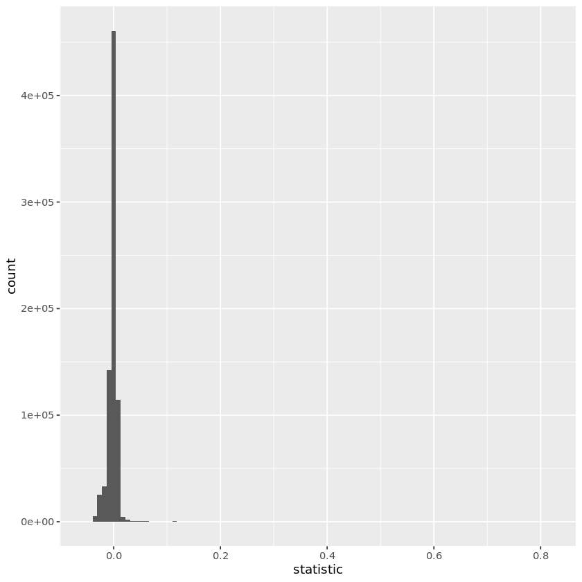

```r
ggplot(data = grm) +
    geom_histogram(aes(x = statistic, y = ..count..), bins = 100)
```

### Estimating variance components

We now use the package gcta to estimate how much of the variance in the phenotype is explained by the SNPs. The command looks like this:  
`gcta64 --grm-gz eye_color-QC --pheno brown_vs_rest.txt --reml --out test`

and outputs `test.hsq` which contains a summary of the restricted maximum likelihood (REML) analysis.

```r
reml <- read.delim('test.hsq', header = TRUE)
reml
```

A data.frame: 10 × 3

| Source <chr> | Variance <dbl> | SE <dbl> |
| --- | --- | --- |
| V(G) | 0.179705 | 0.044949 |
| V(e) | 0.049255 | 0.043289 |
| Vp | 0.228960 | 0.009195 |
| V(G)/Vp | 0.784875 | 0.189935 |
| logL | 301.453000 | NA |
| logL0 | 239.509000 | NA |
| LRT | 123.888000 | NA |
| df | 1.000000 | NA |
| Pval | 0.000000 | NA |
| n | 1260.000000 | NA |

### Estimating variance components for groups of SNPs

I want to know how much of the variance is explained by the genetic variance on chromosome 15 (since this is the most significant one from the GWAS). I run the plink command again to not override the data from before, but this time with the argument --chr 15, to built GRM with variants from chr 15.

`plink --make-grm-gz --bfile eye_color-QC --pheno brown_vs_rest.txt --allow-no-sex --chr 15 --out chr15`

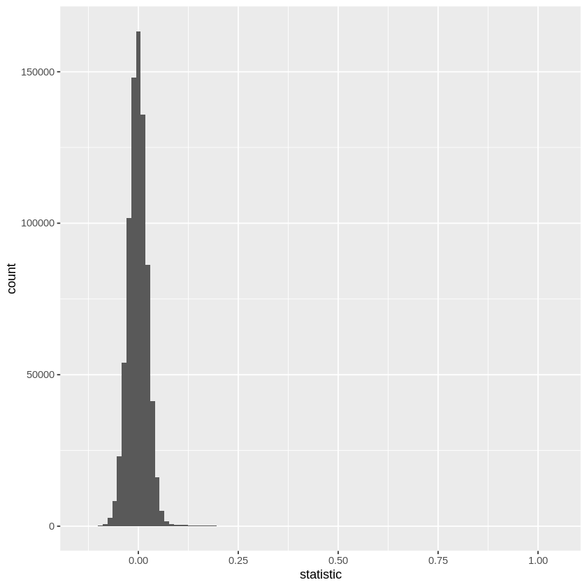

```r
grm_chr15 <- read.table(gzfile('chr15.grm.gz'))
names(grm_chr15) <- c("sample1","sample2","variants","statistic")

grm_chr15 <- grm_chr15 %>%
    filter(sample1 != sample2) %>%
    arrange(desc(statistic))

ggplot(data = grm_chr15) +
    geom_histogram(aes(x = statistic, y = ..count..), bins = 100)
```

Now I run the gcta command with this file:  
`gcta64 --grm-gz chr15 --pheno brown_vs_rest.txt --reml --out test_chr15`

```r
reml_chr15 <- read.delim('test_chr15.hsq', header = TRUE)
reml_chr15

total  <- reml %>%
    filter(Source == 'V(G)/Vp')
chr15 <- reml_chr15 %>%
    filter(Source == 'V(G)/Vp')

chr15$Variance/total$Variance
```

A data.frame: 10 × 3

| Source <chr> | Variance <dbl> | SE <dbl> |
| --- | --- | --- |
| V(G) | 0.095756 | 0.014889 |
| V(e) | 0.136165 | 0.012913 |
| Vp | 0.231921 | 0.009623 |
| V(G)/Vp | 0.412884 | 0.057292 |
| logL | 313.654000 | NA |
| logL0 | 239.509000 | NA |
| LRT | 148.289000 | NA |
| df | 1.000000 | NA |
| Pval | 0.000000 | NA |
| n | 1260.000000 | NA |

0.526050645007167

## Mixed models

I will try to use the GCTA package with the gcta-mlm function to do mixed linear model based association analysis. To start out I compute the GRM. This computes binary files to be used later.  
`plink --make-grm-bin --bfile eye_color-QC --pheno brown_vs_rest.txt --allow-no-sex --out eye_color-QC`

Then I run this GCTA command to do the MLM analysis:  
`gcta64 --mlma --bfile eye_color-QC --grm eye_color-QC --pheno brown_vs_rest.txt --autosome --out eye_color-QC --thread-num 10`

which outputs this file `eye_color-QC.mlma`.

```r
mlma <- read.table("MLM/eye_color-QC.mlma", header = T)
head(mlma %>%
        arrange(p))

sum(mlma$p <= 5e-5)
sum(mlma$p <= 1e-8)

most_significant <- mlma %>%
    filter(p <= 5e-8) %>%
    arrange(p)
```

A data.frame: 6 × 9

|  | Chr <int> | SNP <chr> | bp <int> | A1 <chr> | A2 <chr> | Freq <dbl> | b <dbl> | se <dbl> | p <dbl> |
| --- | --- | --- | --- | --- | --- | --- | --- | --- | --- |
| 1 | 15 | rs1667394 | 28530182 | C | T | 0.227114 | 0.425949 | 0.0246718 | 8.68742e-67 |
| 2 | 15 | rs916977 | 28513364 | T | C | 0.220072 | 0.409857 | 0.0252635 | 3.45224e-59 |
| 3 | 15 | rs8039195 | 28516084 | C | T | 0.204409 | 0.396219 | 0.0269562 | 6.58126e-49 |
| 4 | 15 | rs4778241 | 28338713 | A | C | 0.223810 | 0.341199 | 0.0236963 | 5.26060e-47 |
| 5 | 15 | rs11636232 | 28386626 | T | C | 0.334413 | -0.259936 | 0.0205350 | 1.00795e-36 |
| 6 | 15 | rs3935591 | 28374012 | T | C | 0.209906 | 0.401846 | 0.0331483 | 8.01303e-34 |

71

24

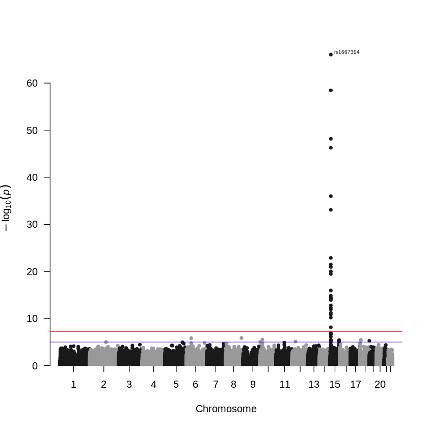

```r
# Make the Manhattan plot on the gwasResults dataset
manhattan(mlma, chr="Chr", bp="bp", snp="SNP", p="p", annotatePval = 5e-8)
```

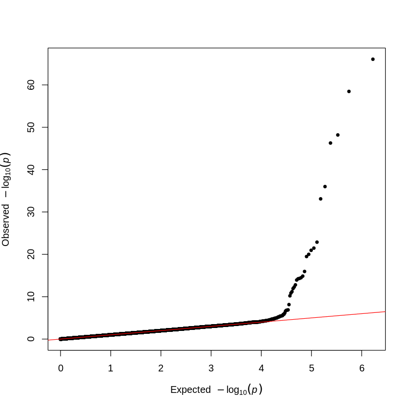

```r
qq(mlma$p)
```

## Replication of paper SNPs

```r
article_genes <- read.table("article_genes.csv", sep = ";", header = T)
head(article_genes)
```

A data.frame: 6 × 10

|  | Region <int> | Chr <chr> | Pos <int> | RS <chr> | Nearest.Gene <chr> | Ref.Allele <chr> | Freq <chr> | Beta <chr> | SE <chr> | P <chr> |
| --- | --- | --- | --- | --- | --- | --- | --- | --- | --- | --- |
| 1 | 1 | 1 | 9166344 | rs6693258 | GPR157 | T | 0,216 | -0,056 | 0,0091 | 9,86E-10 |
| 2 | 2 | 1 | 42110888 | rs6696511 | HIVEP3 | T | 0,382 | 0,109 | 0,0077 | 1,35E-45 |
| 3 | 3 | 1 | 212421629 | rs351385 | DTL | G | 0,58 | -0,083 | 0,0075 | 2,31E-28 |
| 4 | 4 | 1 | 236035805 | rs2385028 | LYST | T | 0,245 | 0,061 | 0,0086 | 2,43E-12 |
| 5 | 5 | 2 | 46233381 | rs13016869 | PRKCE | G | 0,208 | -0,058 | 0,0092 | 2,23E-10 |
| 6 | 6 | 2 | 206950236 | rs112747614 | INO80D | G | 0,696 | 0,054 | 0,0081 | 3,69E-11 |

```r
chromosomes <- tibble(Chr = 15,
                      size = c(102531392))

OCA2 <- tibble(Chr = 15,
               start = 28000021,
               end = 28344461,
               name = "OCA2")

HERC2 <- tibble(Chr = 15,
                start = 28356186,
                end = 28567325,
                name = "HERC2")
```

First, I try to identify SNPs which are directly found in the article.

```r
article_SNPs <- as.vector(article_genes$RS)

identical <- most_significant %>%
    filter(SNP %in% article_SNPs)

identical
```

A data.frame: 3 × 9

| Chr <int> | SNP <chr> | bp <int> | A1 <chr> | A2 <chr> | Freq <dbl> | b <dbl> | se <dbl> | p <dbl> |
| --- | --- | --- | --- | --- | --- | --- | --- | --- |
| 15 | rs1667394 | 28530182 | C | T | 0.2271140 | 0.425949 | 0.0246718 | 8.68742e-67 |
| 15 | rs12593929 | 28359258 | G | A | 0.0977175 | 0.359195 | 0.0433092 | 1.09749e-16 |
| 15 | rs749846 | 28268990 | A | C | 0.1938880 | 0.179045 | 0.0273806 | 6.18821e-11 |

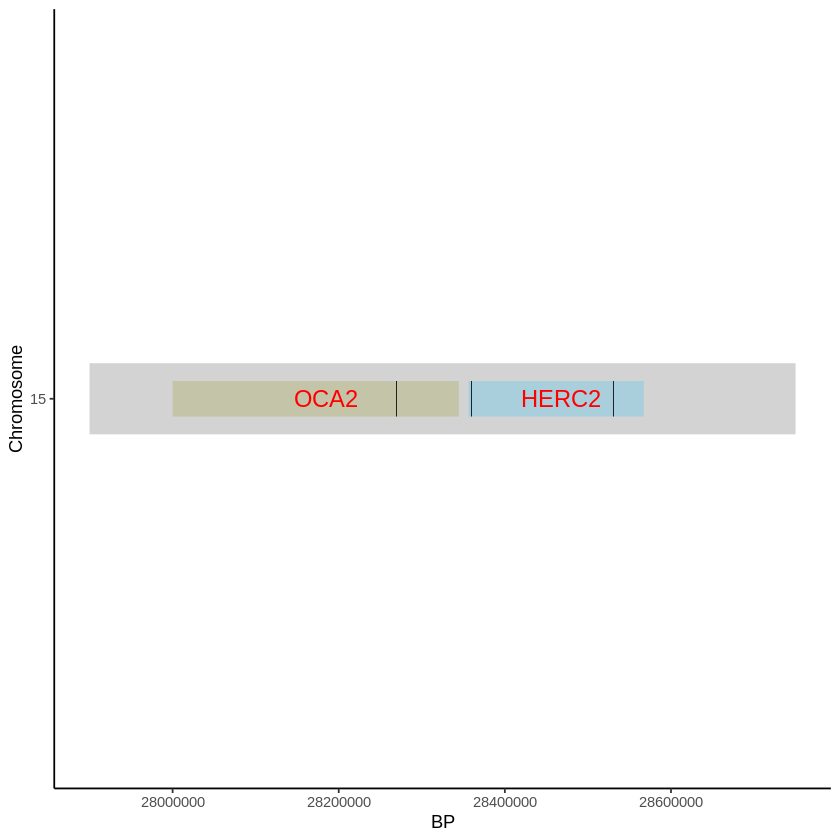

```r
p <- ggplot() +
    geom_segment(data = chromosomes, aes(x = factor(Chr), xend = factor(Chr), y = 27900000, yend = 28750000), color = "lightgrey", size = 20) +
    geom_segment(data = OCA2, aes(x = factor(Chr), xend = factor(Chr), y = start, yend = end), color = "yellow4", alpha = 0.2, size = 10) +
    geom_segment(data = HERC2, aes(x = factor(Chr), xend = factor(Chr), y = start, yend = end), color = "deepskyblue", alpha = 0.2, size = 10) +
    annotate("text", label =HERC2$name, x =factor(HERC2$Chr), y = HERC2$end-100000, size = 5, colour= "red") +
    annotate("text", label =OCA2$name, x =factor(OCA2$Chr), y = OCA2$end-160000, size = 5, colour= "red") +
    theme_classic() +
    coord_flip() +
    xlab("Chromosome") +
    ylab("BP")


p + geom_segment(data = identical, aes(x = factor(Chr), xend = factor(Chr), y = bp, yend = bp+1000), color = "black", size = 10)
```

Now I want to try to investigate if any of the SNPs i've found, is in close proximity to the ones in the article.

```r
find_close_genes <- function(x_away){

    sign_SNPs <- most_significant %>%
        mutate(ref_closest = NA,
               ref_pos = NA,
               ref_Nearest.Gene = NA,
               ref_P = NA)

    gene_pos <- tibble(Pos = article_genes$Pos,
                       Chr = article_genes$Chr,
                       RS = article_genes$RS,
                       Nearest.Gene = article_genes$Nearest.Gene,
                       P = article_genes$P)

    for (i in 1:nrow(sign_SNPs)) {

        pos <- sign_SNPs$bp[i]
        chr <- sign_SNPs$Chr[i]
        test <- gene_pos$Chr == chr & gene_pos$Pos-x_away <= pos & pos <= gene_pos$Pos+x_away

        close_rs <- gene_pos$RS[which(test)]
        ref_pos <- gene_pos$Pos[which(test)]
        gene <- gene_pos$Nearest.Gene[which(test)]
        p_val <- gene_pos$P[which(test)]

        sign_SNPs$ref_closest[i] <- list(close_rs)
        sign_SNPs$ref_pos[i] <- unique(ref_pos)[1]
        sign_SNPs$ref_Nearest.Gene[i] <- list(unique(gene))
        sign_SNPs$ref_P[i] <- list(unique(p_val))

    }

    sign_SNPs <- sign_SNPs %>%
        drop_na()

    return(sign_SNPs)
}
```

```r
bp_1000 <- find_close_genes(1000)
head(bp_1000)

bp_10000 <- find_close_genes(10000)
head(bp_10000)
```

A data.frame: 6 × 13

|  | Chr <int> | SNP <chr> | bp <int> | A1 <chr> | A2 <chr> | Freq <dbl> | b <dbl> | se <dbl> | p <dbl> | ref_closest <list> | ref_pos <int> | ref_Nearest.Gene <list> | ref_P <list> |
| --- | --- | --- | --- | --- | --- | --- | --- | --- | --- | --- | --- | --- | --- |
| 1 | 15 | rs1667394 | 28530182 | C | T | 0.2271140 | 0.425949 | 0.0246718 | 8.68742e-67 | rs1667394 | 28530182 | HERC2 | <1E-330 |
| 2 | 15 | rs4778241 | 28338713 | A | C | 0.2238100 | 0.341199 | 0.0236963 | 5.26060e-47 | rs4778239 | 28337939 | OCA2 | <1E-330 |
| 3 | 15 | rs7174027 | 28328765 | A | G | 0.1416070 | 0.262158 | 0.0284668 | 3.28297e-20 | rs4778137 , rs151090307 | 28327835 | OCA2 | <1E-330 , 6,20E-164 |
| 4 | 15 | rs12593929 | 28359258 | G | A | 0.0977175 | 0.359195 | 0.0433092 | 1.09749e-16 | rs12593929 | 28359258 | HERC2 | <1E-330 |
| 5 | 15 | rs6497253 | 28288549 | A | G | 0.2850700 | 0.169595 | 0.0238688 | 1.20045e-12 | rs1470608 | 28288121 | OCA2 | <1E-330 |
| 6 | 15 | rs749846 | 28268990 | A | C | 0.1938880 | 0.179045 | 0.0273806 | 6.18821e-11 | rs749846 | 28268990 | OCA2 | <1E-330 |

A data.frame: 6 × 13

|  | Chr <int> | SNP <chr> | bp <int> | A1 <chr> | A2 <chr> | Freq <dbl> | b <dbl> | se <dbl> | p <dbl> | ref_closest <list> | ref_pos <int> | ref_Nearest.Gene <list> | ref_P <list> |
| --- | --- | --- | --- | --- | --- | --- | --- | --- | --- | --- | --- | --- | --- |
| 1 | 15 | rs1667394 | 28530182 | C | T | 0.2271140 | 0.425949 | 0.0246718 | 8.68742e-67 | rs1667394 | 28530182 | HERC2 | <1E-330 |
| 2 | 15 | rs4778241 | 28338713 | A | C | 0.2238100 | 0.341199 | 0.0236963 | 5.26060e-47 | rs151090307, rs77542847 , rs76415938 , rs4778239 , rs8026089 | 28329346 | OCA2 | 6,20E-164, <1E-330 |
| 3 | 15 | rs11636232 | 28386626 | T | C | 0.3344130 | -0.259936 | 0.0205350 | 1.00795e-36 | rs150287021, rs12901047 | 28384534 | HERC2 | <1E-330 |
| 4 | 15 | rs7183877 | 28365733 | A | C | 0.0996032 | 0.317382 | 0.0316940 | 1.32378e-23 | rs1129038 , rs77854840, rs12593929 | 28356859 | HERC2 | <1E-330 |
| 5 | 15 | rs7495174 | 28344238 | G | A | 0.0992063 | 0.321384 | 0.0331732 | 3.38930e-22 | rs4778239 , rs8026089 , rs59138695 | 28337939 | OCA2 | <1E-330 |
| 6 | 15 | rs4778138 | 28335820 | G | A | 0.1815100 | 0.267476 | 0.0279602 | 1.10766e-21 | rs4778137 , rs151090307, rs77542847 , rs76415938 , rs4778239 , rs8026089 | 28327835 | OCA2 | <1E-330 , 6,20E-164 |

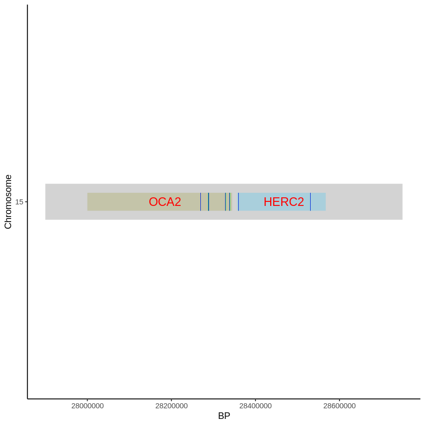

```r
p +
    geom_segment(data = bp_1000, aes(x = factor(Chr), xend = factor(Chr), y = bp, yend = bp+1000), color = "green", size = 10) +
    geom_segment(data = bp_1000, aes(x = factor(Chr), xend = factor(Chr), y = ref_pos, yend = ref_pos+1000), color = "blue", size = 10)
```

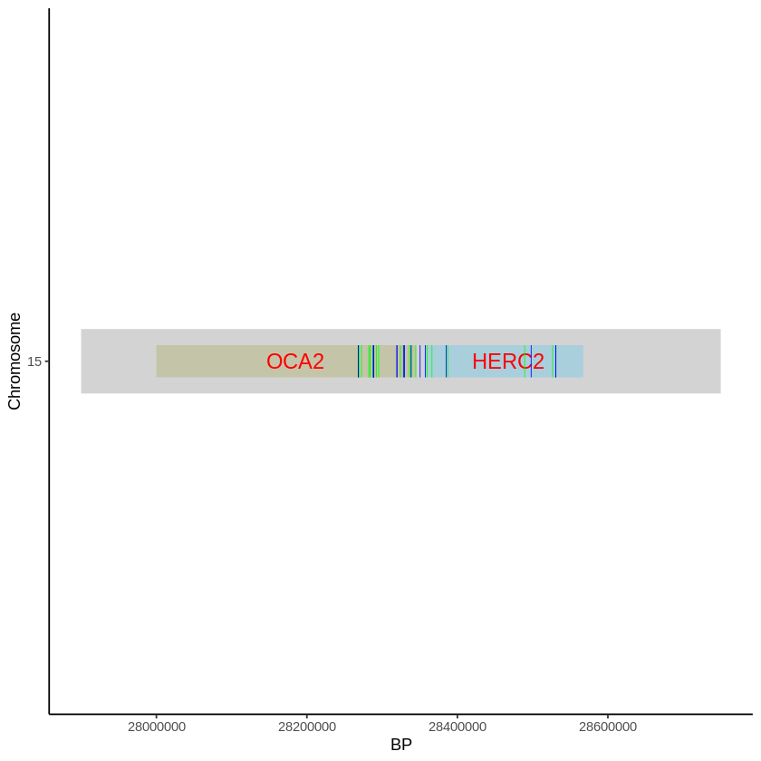

```r
p +
    geom_segment(data = bp_10000, aes(x = factor(Chr), xend = factor(Chr), y = bp, yend = bp+1000), color = "green", size = 10) +
    geom_segment(data = bp_10000, aes(x = factor(Chr), xend = factor(Chr), y = ref_pos, yend = ref_pos+1000), color = "blue", size = 10)
```